# Travel Trends:HOW Do Americans Get Where They’re Going?

Brianna Lawton, Zhiyi Zheng, Mariana Chiozza, Amrita Goswamy,and Waruni Wijayasinghe

December 12, 2018

# 1. Introduction

How many modes of transportation do you take to get to work or school? Well, your response is dependent upon several factors that influence your choice of mode. This research study aims to explore the various modes of transportation available in the United State (U.S.) and potential factors that influence a person’s choice of mode they use to travel from one point to another. There are various modes of transportation available for the American population to use. The U.S. department of transportation describes the basic five modes of transport to be: rail, water, road, air, and pipeline. Under each of these five modes, there is a further breakdown of micro-mobility transportation modes like car, bus, bike, walk, taxi, or train. The idea of mode choice is important because it can help identify what modes are being heavily utilized, which can help decide where to direct funds to maintain and sustain transportation infrastructure. It can also identify where to implement countermeasures to reduce traffic congestion, which then reduces travel time, which in return can reduce travelers’ costs and vehicle emissions. The objectives of this research study is to investigate the different modes of travel available in the U.S., recognize variables that could potentially influence mode choice, and explore trends between a mode and influential variables. This study uses the 2017 +-9National Household Travel Survey (NHTS) dataset to display the trends and the impact household characteristics like family income, family size, the travel day, and the area type that a household is located have on the mode choice that a person or household chooses to travel by to get from origin to destination.

# 2. Data Description

The National Household Travel Survey (NHTS) is conducted by the Federal Highway Administration (FHWA) and is the source of information about travel by U.S. residents in all 50 States and Washington D.C. The NHTS is the authoritative source on the travel behavior of the American public. It is the only source of national data that allows one to analyze trends in personal and household travel. It includes daily non-commercial travel by all modes, including characteristics of the people traveling, their household, and their vehicles. This inventory of travel behavior includes trips made by all modes of travel (i.e., private vehicle, public transportation, pedestrian, and cycling) and for all purposes (e.g., travel to work, school, recreation, and personal/family trips). It provides information to assist transportation planners and policymakers who need comprehensive data on travel and transportation patterns in the United States. Data from a total of 129,696 households were included in the 2017 NHTS dataset with 58 column variables (household file). The NHTS data is organized into the following four data files: Household File: One record per household, Person File: One record for each household member, Travel Day Trip File: One record for each trip reported by each household member of age 5+, and Vehicle File: One record for each household vehicle. The first NHTS was first conducted in 1969 and was originally called the Nationwide Personal Transportation Survey (NPTS). It was then renamed to the NHTS in 2001. The 2017 NHTS is the eighth and most recent survey in the NHTS/NPTS series and updates information gathered in prior NPTSs in 1969, 1977, 1983, 1990, and 1995 and NHTSs in 2001 and 2009. For this research study, the 2017 NHTS dataset was used to explore different available modes of transportation in the U.S. and the household characteristics that could potentially influence a person’s mode choice. The 2017 household and person files were used to run analysis and generate results from the datasets. The following variables within the household file were used to analyze and visualize the data (Table 1 below). The household identifier (HOUSEID) played a key role in aggregating data towards the proper household. The household state (HHSTATE) variable helped pinpoint the trends of different travel modes in different states across the U.S. The variables household income (HHFAMINC), household size (HHSIZE), travel day (TRAVDAY), and area type (URBRUR) were looked at as independent variables that were each compared to the frequency use of each travel mode variable (CAR, TAXI, BUS, TRAIN, BIKE, WALK) to analyze how influential each characteristic is to select a particular mode to travel.

TABLE 1 Important Variables from Household Dataset Variable Description

HOUSEID = Household Identifier

HHSTATE = Household State

HHFAMINC = Household Income

HHSIZE = Count of household members

TRAVDAY = Travel day - day of week

URBRUR = Household in urban/rural area

CAR = Frequency of Personal Vehicle Use for Travel

TAXI = Frequency of Taxi Service or Rideshare Use for Travel

BUS = Frequency of Bus Use for Travel

TRAIN = Frequency of Train Use for Travel

BIKE = Frequency of Bicycle Use for Travel

WALK = Frequency of Walking for Travel

# 3. Literature Review

A brief literature review was conducted to see the previous statistics of mode choice. The Bureau of Transportation Statistics shows that the use of personal vehicle (car) is the predominant mode for all travelers (BTS, 2006). Additionally, rural areas use it for 95 % of long-distance trips, while personal vehicle (car) is used for only 87 % of trips originating in urban areas. This may be due to the fact that public transportation and other modes of transportation are available in urban areas (BTS, 2006). Similarly, 1 % of travelers use rail from urban areas, compared to about one-half of 1 % in rural areas (BTS, 2006). Mode choice also varies by trip purpose, household income, demographics, population per sq. mi., etc. (FHWA).

# 4. Methodology

(-1), (-7), (-8), (-9) entries in CAR, TAXI, BUS, WALK, HHFAMINC columns were replaced by NA. After that, All the rows with NAs were removed. levels of CAR, TAXI, BUS, WALK, TRAVDAY, URBRUR were renamed and reordered. Then the frequency distributions for each travel mode (CAR, BIKE, WALK, TRAIN, BUS, TAXI) were plotted using ggplot2 package. Also, how frequent the travel modes CAR, WALK, BUS, TAXI, BIKE, TRAIN have been used in 2017 across the United States were plotted using choropleth maps. Out of those travel modes, TAXI, WALK, CAR, BUS was further analyzed by taking frequency counts and proportions using dplyr package. Further, each of those travel modes (TAXI, WALK, CAR, BUS) were then compared with the influential variables HHSIZE, HHFAMINC, URBRUR and TRAVDAY using bar charts (ggplot2 package) and mosaic plot (ggmosaic package). Finally, 2017 NHTS response rates were calculated using dplyr package.

# 5. Analysis & Results

The following R code executes and displays each step that each team member coded themself for their own particular mode choice (BUS=Brinna; Taxi=Zhiyi; Walk=Mariana; Car=Waruni). For the sake of space and summarizing purposes we combined the code since each of our codes separately was very similar, we combined all our code into a master file.

Part 1: Load Packages included

```r
library(tidyverse)
```

```r
library(readr)
library(ggplot2)
library(boxr)
library(data.table)
library(tidyr)
```

Part 2: loading the Data from github and extracting data in use

```r
hhpub <- read_csv ("https://raw.githubusercontent.com/zoeyzhengzy/stat579_final_project/master/hhpub-revised.csv")
states <- read_csv ("https://raw.githubusercontent.com/zoeyzhengzy/stat579_final_project/master/states.csv")
modes <- hhpub %>% select("HOUSEID", "HHSTATE", "URBRUR", "HHFAMINC", "HHSIZE", "WRKCOUNT", "TRAVDAY", "WALK","BIKE", "CAR", "TAXI", "BUS", "TRAIN" )
```

Part 3: Cleaning data

```r
# Cleaning all the non-sense response

modes$HHFAMINC <- replace(modes$HHFAMINC, modes$HHFAMINC %in% c(-7, -8, -9), NA)
modes$WALK <- replace(modes$WALK, modes$WALK %in% c(-7, -8, -9), NA)
modes$CAR <- replace(modes$CAR, modes$CAR %in% c(-1, -8, -9), NA)
modes$TAXI <- replace(modes$TAXI, modes$TAXI %in% c(-7, -8, -9), NA)
modes$BUS <- replace(modes$BUS, modes$BUS %in% c(-7, -8, -9), NA)
modes$TRAIN <- replace(modes$BUS, modes$BUS %in% c(-7, -8, -9), NA)
modes$BIKE <- replace(modes$BUS, modes$BUS %in% c(-7, -8, -9), NA)

modes <- na.omit(modes)
```

Part 4: Change levels of all mode variable levels and certain variables

```r
# Change levels of all 7 travel mode variables

modes$TAXI <- factor(modes$TAXI, levels = c("1","2","3","4","5"), labels = c("Daily", "A few times a week","A few times a month", "A few times a year","Never"))

modes$BUS <- factor(modes$BUS, levels = c("1","2","3","4","5"), labels = c("Daily", "A few times a week","A few times a month", "A few times a year","Never"))

modes$WALK <- factor(modes$WALK, levels = c("1","2","3","4","5"), labels = c("Daily", "A few times a week","A few times a month", "A few times a year","Never"))

modes$CAR <- factor(modes$CAR, levels = c("1","2","3","4","5"), labels = c("Daily", "A few times a week","A few times a month", "A few times a year","Never"))

modes$TRAIN <- factor(modes$TRAIN, levels = c("1","2","3","4","5"), labels = c("Daily", "A few times a week","A few times a month", "A few times a year","Never"))

modes$BIKE <- factor(modes$BIKE, levels = c("1","2","3","4","5"), labels = c("Daily", "A few times a week","A few times a month", "A few times a year","Never"))




states$TAXI <- factor(states$TAXI, levels = c("1","2","3","4","5"), labels = c("Daily", "A few times a week","A few times a month", "A few times a year","Never"))

states$BUS <- factor(states$BUS, levels = c("1","2","3","4","5"), labels = c("Daily", "A few times a week","A few times a month", "A few times a year","Never"))

states$WALK <- factor(states$WALK, levels = c("1","2","3","4","5"), labels = c("Daily", "A few times a week","A few times a month", "A few times a year","Never"))

states$CAR <- factor(states$CAR, levels = c("1","2","3","4","5"), labels = c("Daily", "A few times a week","A few times a month", "A few times a year","Never"))

states$TRAIN <- factor(states$TRAIN, levels = c("1","2","3","4","5"), labels = c("Daily", "A few times a week","A few times a month", "A few times a year","Never"))

states$BIKE <- factor(states$BIKE, levels = c("1","2","3","4","5"), labels = c("Daily", "A few times a week","A few times a month", "A few times a year","Never"))



# Change levels of other variables needed
modes$HHFAMINC[modes$HHFAMINC == 1] <- "Less than $10,000"
modes$HHFAMINC[modes$HHFAMINC == 2] <- "$10,000 to $14,999"
modes$HHFAMINC[modes$HHFAMINC == 3] <- "$15,000 to $24,999"
modes$HHFAMINC[modes$HHFAMINC == 4] <- "$25,000 to $34,999"
modes$HHFAMINC[modes$HHFAMINC == 5] <- "$35,000 to $49,999"
modes$HHFAMINC[modes$HHFAMINC == 6] <- "$50,000 to $74,999"
modes$HHFAMINC[modes$HHFAMINC == 7] <- "$75,000 to $99,999"
modes$HHFAMINC[modes$HHFAMINC == 8] <- "$100,000 to $124,999"
modes$HHFAMINC[modes$HHFAMINC == 9] <- "$125,000 to $149,999"
modes$HHFAMINC[modes$HHFAMINC == 10] <- "$150,000 to $199,999"
modes$HHFAMINC[modes$HHFAMINC == 11] <- "$200,000 or more"

## TRAVDAY variable
modes$TRAVDAY[modes$TRAVDAY == 1] <- "Sunday"
modes$TRAVDAY[modes$TRAVDAY == 2] <- "Monday"
modes$TRAVDAY[modes$TRAVDAY == 3] <- "Tuesday"
modes$TRAVDAY[modes$TRAVDAY == 4] <- "Wednesday"
modes$TRAVDAY[modes$TRAVDAY == 5] <- "Thursday"
modes$TRAVDAY[modes$TRAVDAY == 6] <- "Friday"
modes$TRAVDAY[modes$TRAVDAY == 7] <- "Saturday"

## URBRUR variable
modes$URBRUR<-colnames(modes)[3] <- "Area Type"
modes$`Area Type`<-factor(modes$`Area Type`, labels=c("Urban", "Rural"))
```

# Overview of All Travel Modes

Exploring the trends of all modes used as a travel mode in the U.S. using frequency distribution

A combined frequency distribution of all the different modes were created to check the use of each mode as a whole. The figure shows that CAR is used daily predominantly followed by WALK, BUS, BIKE and TRAIN. TAXI is rarely used daily. It was also seen that TRAIN, TAXI, PARA, BIKE, BUS was never used by many travelers followed by a lower percentage of WALK and CAR mode. Also WALK and CAR use is above the other modes for people using it a few times a week. TAXI, TRAIN, BUS, WALK and BIKE have higher respondents for using it a few times a month. As was seen from the maps the WALK mode is almost equally distributed among the different levels.

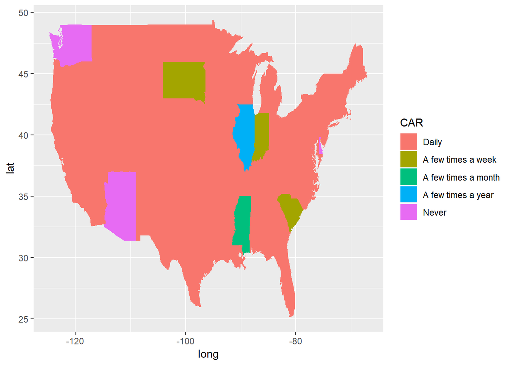

```r
#part 5
overview <- subset(modes, select=c("WALK", "BIKE", "CAR", "TAXI", "BUS", "TRAIN"))

overview_all_modes <- overview %>% gather(ModeType, WALK:TRAIN)
names(overview_all_modes)[2] <- "Frequency"

overview_all_modes$Frequency <- factor(overview_all_modes$Frequency,
                                       levels = c("Daily", "A few times a week","A few times a month", "A few times a year","Never"))



states %>%  ggplot(aes(x = long, y = lat, fill = CAR, group = group, order=CAR)) + geom_polygon()
```

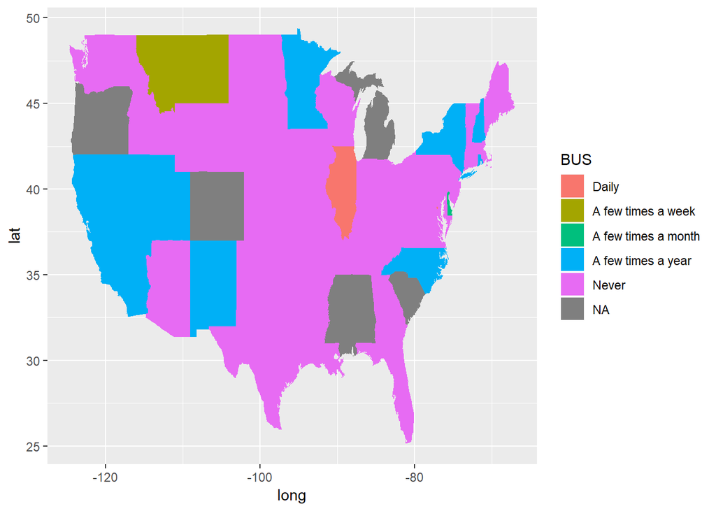

```r
states %>%  ggplot(aes(x = long, y = lat, fill = BUS, group = group,order=BUS)) + geom_polygon()
```

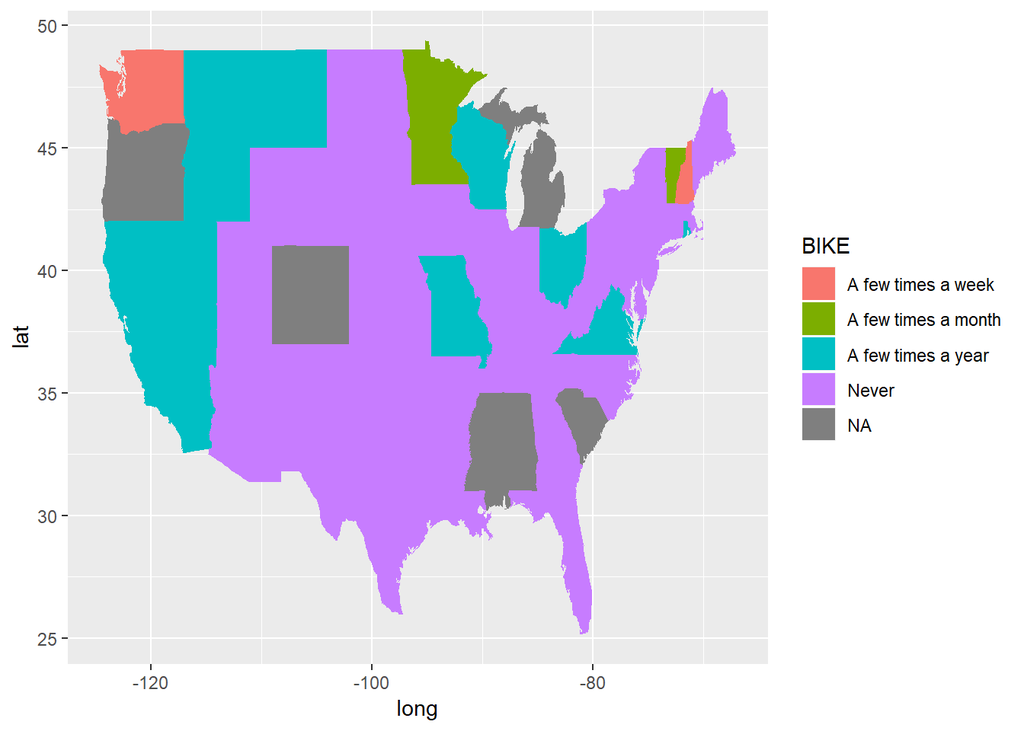

```r
states %>%  ggplot(aes(x = long, y = lat, fill = BIKE, group = group,order=BIKE)) + geom_polygon()
```

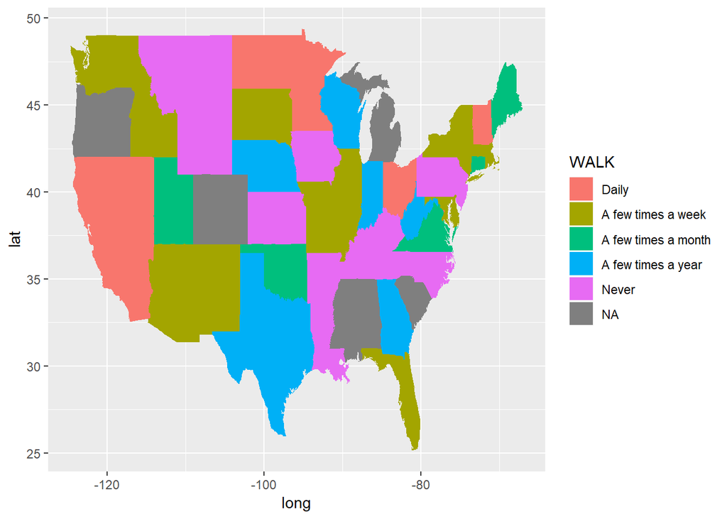

```r
states %>%  ggplot(aes(x = long, y = lat, fill = WALK, group = group,order=WALK)) + geom_polygon()
```

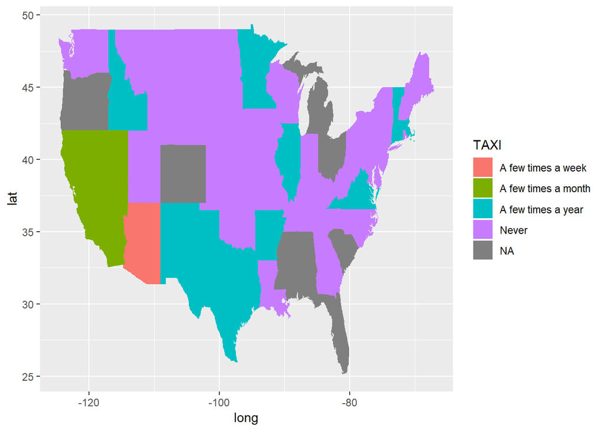

```r
states %>%  ggplot(aes(x = long, y = lat, fill = TAXI, group = group,order=TAXI)) + geom_polygon()
```

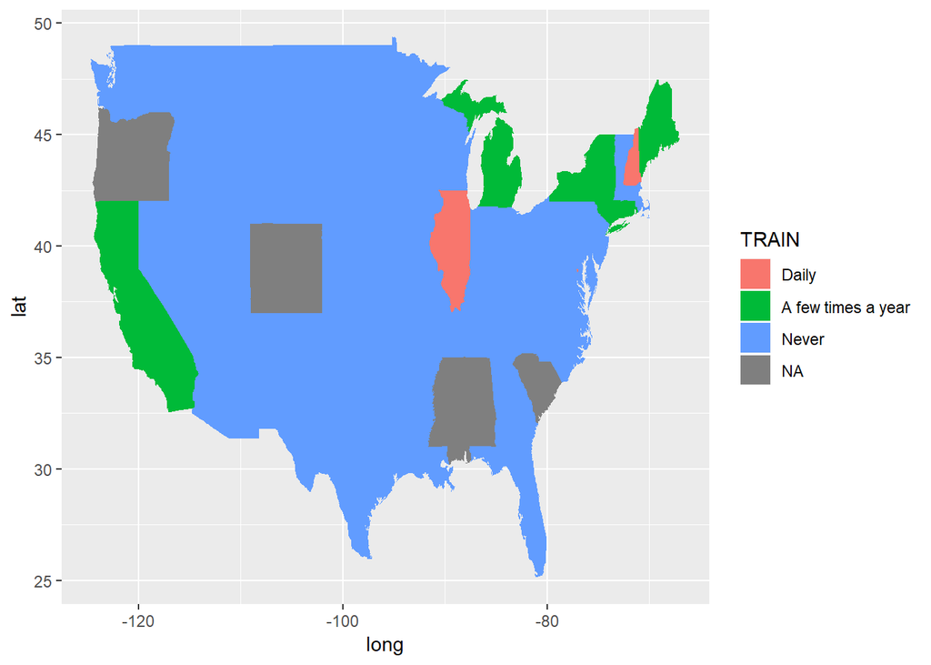

```r
states %>%  ggplot(aes(x = long, y = lat, fill = TRAIN, group = group,order=TRAIN)) + geom_polygon()
```

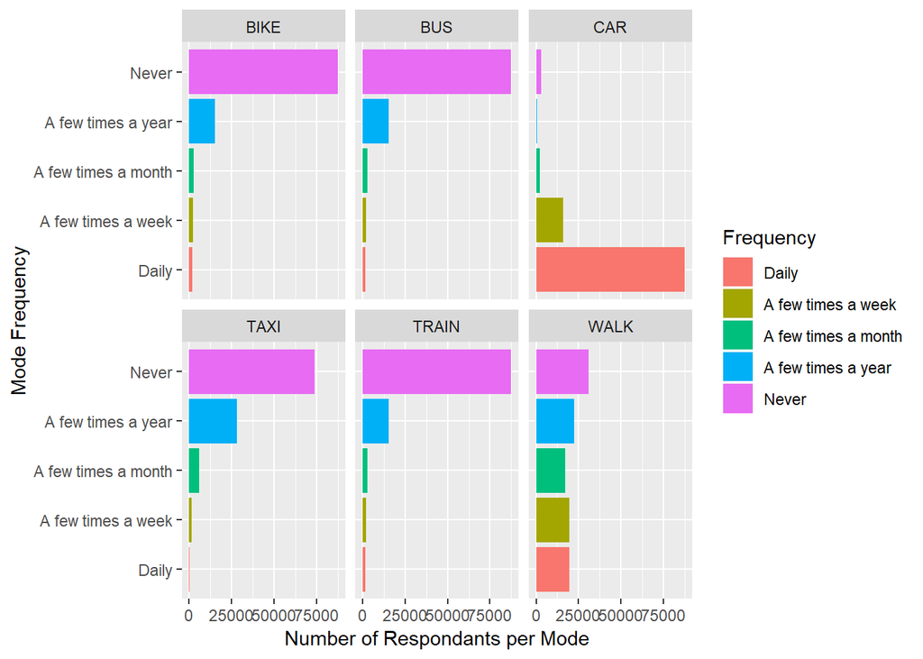

```r
overview_all_modes %>%
  ggplot(aes(x = Frequency, fill =Frequency)) +
  geom_bar() +
  facet_wrap(~ModeType) +
  coord_flip() +
  xlab("Mode Frequency") +
  ylab("Number of Respondants per Mode")
```

Looking at the above graph, it can be observed that the frequency of using cars has an interesting trend when compared with other travel modes. And frequency of walking for travel also seems fascinating as well, since the frequencies of each level seems quite the same. Using bus and taxi for travel has a similar trend and it was worth looking into. Therefore, the further extent of our study analyzes the relationship between the modes: CAR, BUS, TAXI, and WALK and the household characteristics that influence a person in choosing this mode to travel.

# Analysis in 4 travel modes we picked: TAXI, WALK, CAR, BUS

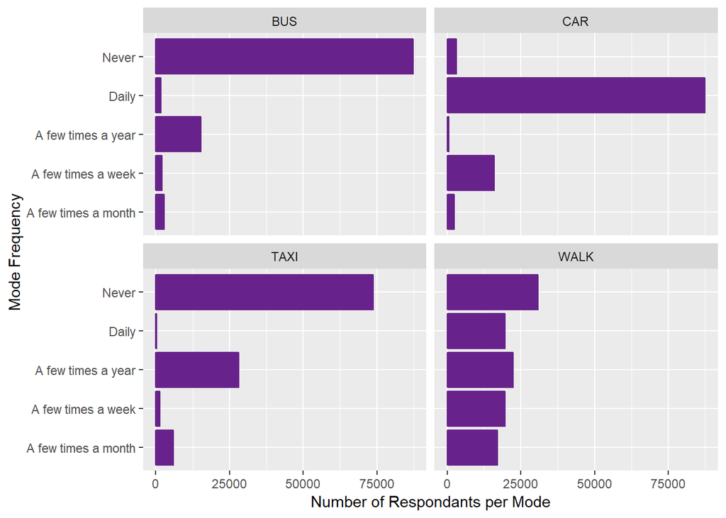

```r
#part 6
# Frequency distribution for each mode
analysis <- modes %>% gather(mode, level, "WALK", "CAR", "TAXI", "BUS")

analysis %>%
  ggplot(aes(x=level)) +
  geom_bar(col="darkorchid4", fill="darkorchid4") +
  coord_flip() + facet_wrap(~mode) + xlab("Mode Frequency") + ylab("Number of Respondants per Mode")
```

```r
# Table of Frequency proportions for each mode and level
analysis %>%
  group_by(mode, level) %>%
  summarize(n=n()) %>%
  mutate(level_rate = n/109534*100)
```

```
## # A tibble: 20 x 4
## # Groups:   mode [4]
##    mode  level                   n level_rate
##    <chr> <chr>               <int>      <dbl>
##  1 BUS   A few times a month  2782      2.54
##  2 BUS   A few times a week   2181      1.99
##  3 BUS   A few times a year  15390     14.1
##  4 BUS   Daily                1760      1.61
##  5 BUS   Never               87421     79.8
##  6 CAR   A few times a month  2365      2.16
##  7 CAR   A few times a week  15916     14.5
##  8 CAR   A few times a year    652      0.595
##  9 CAR   Daily               87477     79.9
## 10 CAR   Never                3124      2.85
## 11 TAXI  A few times a month  6005      5.48
## 12 TAXI  A few times a week   1351      1.23
## 13 TAXI  A few times a year  28141     25.7
## 14 TAXI  Daily                 232      0.212
## 15 TAXI  Never               73805     67.4
## 16 WALK  A few times a month 17073     15.6
## 17 WALK  A few times a week  19593     17.9
## 18 WALK  A few times a year  22423     20.5
## 19 WALK  Daily               19550     17.8
## 20 WALK  Never               30895     28.2
```

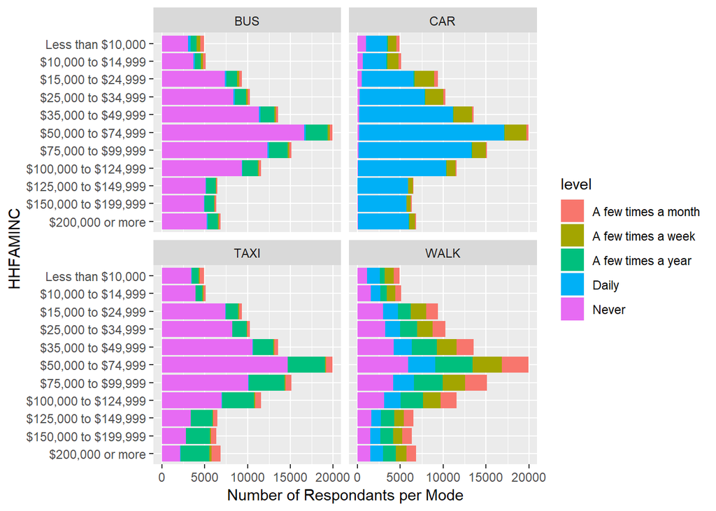

```r
# Variables influencing the mode of travel

## Income
analysis$HHFAMINC <- factor(analysis$HHFAMINC,
                            levels = c("$200,000 or more", "$150,000 to $199,999", "$125,000 to $149,999", "$100,000 to $124,999", "$75,000 to $99,999", "$50,000 to $74,999", "$35,000 to $49,999", "$25,000 to $34,999", "$15,000 to $24,999", "$10,000 to $14,999", "Less than $10,000"))

analysis %>%
  ggplot(aes(x=HHFAMINC, fill=level)) +
  geom_bar() +
  coord_flip() + facet_wrap(~mode) +  ylab("Number of Respondants per Mode")
```

# Exploring the Household Income level as an influence for choosing modes of travel

The graph above shows that the proportion of people who use BUS seems to be influenced by their income level. Around 80% of people with income levels of $200,000 or more never use BUS as a mode of transportation, while this proportion is reduced to 62% for people with income levels of $10,000 or less. Similarly, a high proportion (86%) of people with high income levels use CAR daily while only 48% of people use CAR daily if their income is less than $10,000. Interestingly, people with an income level of $200,000 or more use TAXI a few times a year (50%) or never (30%). These proportions are reversed gradually as the income level decrease to reach 70% for people who never use TAXI and 15% for people use TAXI a few times a year, when the income level is as low as $10,000 or less. Finally, choosing WALK as a mode of transportation seems to not be influenced by the income level and frequency levels were evenly distributed.

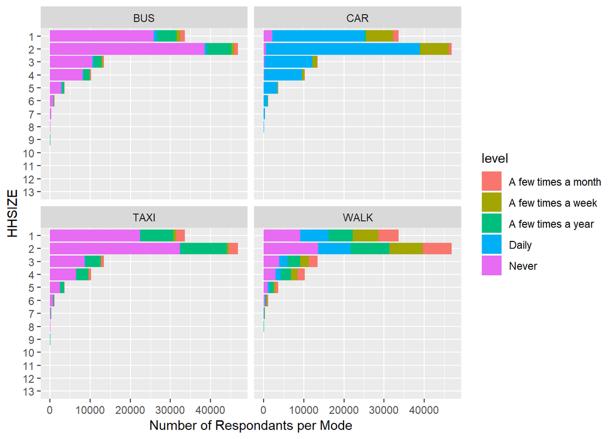

```r
## House size
analysis$HHSIZE<-as.factor(analysis$HHSIZE)
analysis$HHSIZE <- factor(analysis$HHSIZE, levels = c("13", "12", "11", "10", "9", "8", "7", "6", "5", "4", "3", "2", "1"))

analysis %>%
  ggplot(aes(x=HHSIZE, fill=level)) +
  geom_bar() +
  coord_flip() + facet_wrap(~mode) +  ylab("Number of Respondants per Mode")
```

# Exploring the number of people living in a Household as an influence for choosing modes of travel

The graph above shows that the frequency of using BUS or WALK as a mode of transportation is not influenced by the number of people living in each house. Regardless of the number of members in a household, 76 % of people never use BUS. The frequency distribution of WALK is evenly distributed across all levels. On the other hand, the proportion of people using CAR daily increase as the number of members in a household. In households with 1 member, 70% of people use car daily while the proportion of people using CAR daily increase to 92% in households with 5 members. Regarding TAXI as a mode of transportation, in household with 1 member the proportion of people who never use TAXI is 67% while in households with 10 members the proportions of people never using TAXI rise to 76%.

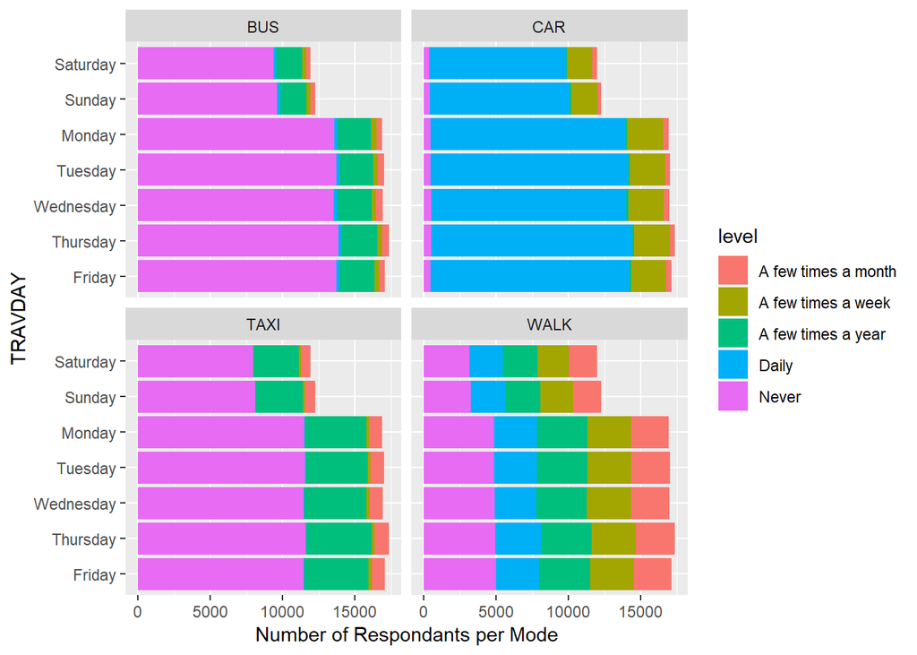

```r
## Travel day
analysis$TRAVDAY <- factor(analysis$TRAVDAY, levels = c("Friday", "Thursday", "Wednesday", "Tuesday", "Monday", "Sunday", "Saturday"))

analysis %>%
  ggplot(aes(x=TRAVDAY, fill=level)) +
  geom_bar() +
  coord_flip() +
  facet_wrap(~mode) +  ylab("Number of Respondants per Mode")
```

# Exploring the Travel Day as an influence for choosing modes of travel

The above graph shows that people seems not to change their mode of transportation based on the day of the week. For example, the proportion of people using BUS on Wednesday is the same as the proportion of people using BUS on any other day of the week. All modes of travel follow the same trend. Therefore, regardless of the day of the week, 80% of people never use BUS, 80% of people use CAR daily and 70% of people never use TAXI. The frequency of walking is evenly distributed along all levels and these proportions also do not change with the day of the week.

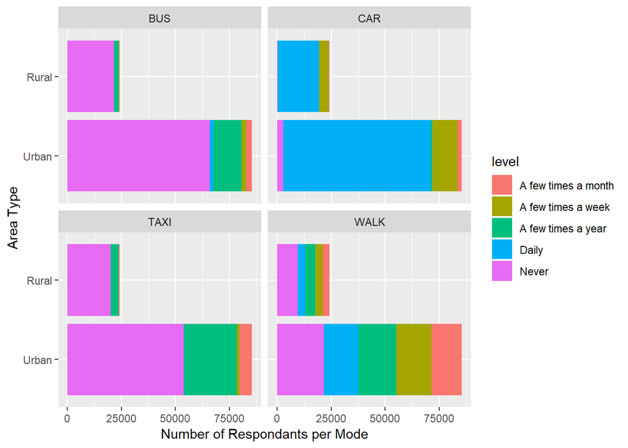

```r
## Area Type
analysis %>%
  ggplot(aes(x=`Area Type`, fill=level)) +
  geom_bar() +
  coord_flip() +
  facet_wrap(~mode) +  ylab("Number of Respondants per Mode")
```

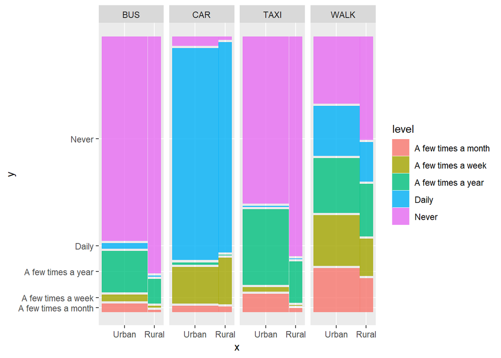

```r
## Area type (GGMosaic)
#install.packages("ggmosaic")
library(ggmosaic)
## had to rename the area type variable in order for mosaic plot to run
analysis2 <- analysis %>%
  mutate(area_type = `Area Type`)
ggplot(data = analysis2) +  geom_mosaic(aes(x = product(level, area_type), fill = level)) + facet_grid(~mode)
```

# Exploring the Area Type as an influence for choosing modes of travel

The above graph show that the area type showed to influence the mode of transportation people use. The proportion of people who lives in rural areas and never use BUS is 89% while the proportion of people never using BUS who live in urban areas is 77%. As per the use of TAXI, 82% of the people who lives in rural areas never use TAXI while for people living in urban areas this proportion is 63%. The proportions for WALK mode of transportation were 38% for people living in rural areas and never walking and 25% for people living in urban areas. Finally, the daily use of CAR was not influenced by the area type. The proportion of people using CAR daily is 80% for both area types.

```r
# Table of Frequency proportions for each mode, level and variable
analysis %>%
  group_by(`Area Type`, mode, level)%>%
  summarize(n=n()) %>%
  mutate(Prop = n / sum(n))
```

```
## # A tibble: 40 x 5
## # Groups:   Area Type, mode [8]
##    `Area Type` mode  level                   n    Prop
##    <fct>       <chr> <chr>               <int>   <dbl>
##  1 Urban       BUS   A few times a month  2623 0.0307
##  2 Urban       BUS   A few times a week   2053 0.0240
##  3 Urban       BUS   A few times a year  13188 0.154
##  4 Urban       BUS   Daily                1677 0.0196
##  5 Urban       BUS   Never               65867 0.771
##  6 Urban       CAR   A few times a month  1920 0.0225
##  7 Urban       CAR   A few times a week  11690 0.137
##  8 Urban       CAR   A few times a year    601 0.00704
##  9 Urban       CAR   Daily               68326 0.800
## 10 Urban       CAR   Never                2871 0.0336
## # ... with 30 more rows
```

```r
analysis %>%
  group_by(HHSIZE, mode, level)%>%
  summarize(n=n()) %>%
  mutate(Prop = n / sum(n))
```

```
## # A tibble: 204 x 5
## # Groups:   HHSIZE, mode [52]
##    HHSIZE mode  level                  n  Prop
##    <fct>  <chr> <chr>              <int> <dbl>
##  1 13     BUS   Never                  1   1
##  2 13     CAR   Daily                  1   1
##  3 13     TAXI  Never                  1   1
##  4 13     WALK  Never                  1   1
##  5 12     BUS   Never                  2   1
##  6 12     CAR   Daily                  2   1
##  7 12     TAXI  A few times a year     1   0.5
##  8 12     TAXI  Never                  1   0.5
##  9 12     WALK  A few times a year     2   1
## 10 11     BUS   Never                  4   1
## # ... with 194 more rows
```

```r
analysis %>%
  group_by(HHFAMINC, mode, level)%>%
  summarize(n=n()) %>%
  mutate(Prop = n / sum(n))
```

```
## # A tibble: 220 x 5
## # Groups:   HHFAMINC, mode [44]
##    HHFAMINC         mode  level                   n    Prop
##    <fct>            <chr> <chr>               <int>   <dbl>
##  1 $200,000 or more BUS   A few times a month   188 0.0274
##  2 $200,000 or more BUS   A few times a week    110 0.0160
##  3 $200,000 or more BUS   A few times a year   1209 0.176
##  4 $200,000 or more BUS   Daily                  85 0.0124
##  5 $200,000 or more BUS   Never                5270 0.768
##  6 $200,000 or more CAR   A few times a month   143 0.0208
##  7 $200,000 or more CAR   A few times a week    684 0.0997
##  8 $200,000 or more CAR   A few times a year     32 0.00466
##  9 $200,000 or more CAR   Daily                5958 0.868
## 10 $200,000 or more CAR   Never                  45 0.00656
## # ... with 210 more rows
```

```r
analysis %>%
  group_by(TRAVDAY, mode, level)%>%
  summarize(n=n()) %>%
  mutate(Prop = n / sum(n))
```

```
## # A tibble: 140 x 5
## # Groups:   TRAVDAY, mode [28]
##    TRAVDAY mode  level                   n    Prop
##    <fct>   <chr> <chr>               <int>   <dbl>
##  1 Friday  BUS   A few times a month   394 0.0230
##  2 Friday  BUS   A few times a week    338 0.0198
##  3 Friday  BUS   A few times a year   2396 0.140
##  4 Friday  BUS   Daily                 237 0.0139
##  5 Friday  BUS   Never               13729 0.803
##  6 Friday  CAR   A few times a month   386 0.0226
##  7 Friday  CAR   A few times a week   2404 0.141
##  8 Friday  CAR   A few times a year     91 0.00532
##  9 Friday  CAR   Daily               13751 0.804
## 10 Friday  CAR   Never                 462 0.0270
## # ... with 130 more rows
```

```r
# How representative is the survey across all US (map)?

library(tidyverse)
library(maps)
perpub <- read_csv ("https://raw.githubusercontent.com/zoeyzhengzy/stat579_final_project/master/perpub-revised.csv")
data(fbi, package="classdata")
fbi17 <- fbi %>% filter(Year == 2017)

states<-map_data("state")

fbi17$region <- tolower(fbi17$State)

combined <- fbi17 %>% left_join(states, by="region")

combined<-combined %>% rename(HHSTATE=Abb)

perpubset<-perpub %>% select(HOUSEID, HHSTATE)

nomatch <- combined %>% anti_join(perpubset, by="HHSTATE")
unique(nomatch$HHSTATE)
```

```
## [1] "D.C." "PR"
```

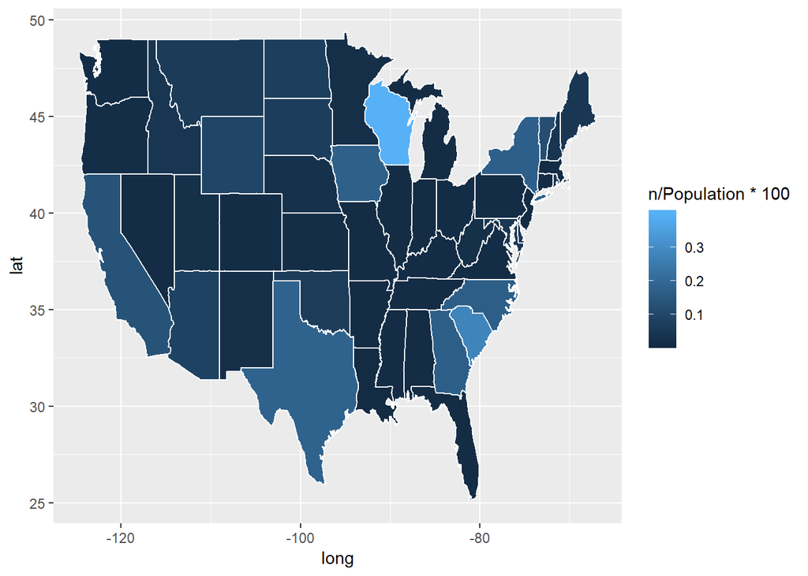

```r
combined<-combined %>% filter(HHSTATE!='PR')

perpubset[62401:62924, 2] <- "D.C."

combined<-combined%>%
  select(HHSTATE,Year, Population,long,lat,group,order)


perpubset2<-perpubset%>%
  group_by(HHSTATE)%>%
summarise(n=n())


combined2 <- combined %>% left_join(perpubset2, by="HHSTATE")

combined3<-combined2%>%
  filter(HHSTATE!='AK')

combined4<-combined3%>%
  filter(HHSTATE!='HI')

library(tidyverse)

combined4 %>%
  arrange(lat)%>%
  arrange(order)%>%
  ggplot(aes(x = long, y = lat, fill=n/Population*100, group=group)) +
  geom_polygon(colour="white")
```

```r
combined4<-combined4%>%
  mutate(rate=n/Population*100)


combined4 <- arrange(combined4, rate)
combined5 <- combined4[!duplicated(combined4$HHSTATE),]

combined5 <- arrange(combined5, -rate)
combined5[1:10, ]
```

```
##    HHSTATE Year Population       long      lat group order     n
## 1       WI 2017    5795483  -87.80006 42.50201    62 15143 23179
## 2       SC 2017    5024369  -83.10753 34.99053    47 11441 13923
## 3       TX 2017   28304596  -94.49792 33.66700    50 12203 51262
## 4       IA 2017    3145711  -91.22634 43.49895    14  3539  5482
## 5       NY 2017   19849399  -73.92874 40.80605    34  9050 34463
## 6       NC 2017   10273419  -75.89399 36.55471    38  9549 17554
## 7       GA 2017   10429379  -80.89018 32.03980    10  2335 17664
## 8       CA 2017   39536653 -120.00601 42.00927     4   667 53512
## 9       VT 2017     623657  -73.36152 45.01157    52 13352   759
## 10      WY 2017     579315 -109.05106 40.99513    63 15532   540
##          rate
## 1  0.39994941
## 2  0.27710942
## 3  0.18110840
## 4  0.17426903
## 5  0.17362239
## 6  0.17086814
## 7  0.16936771
## 8  0.13534783
## 9  0.12170151
## 10 0.09321354
```